# How Passengers Spend Their Time on the Bus

## Introduction

This visual data story explores how passengers spend their time on the bus. The data was collected through observational logging using a Google Form. Each observation recorded what a passenger was doing, whether they were wearing headphones, the estimated length of their bus trip, and the time of day.

## What passengers were doing

The first visualisation shows the most common passenger activities observed during bus trips. This helps show which behaviours were most typical in the data.

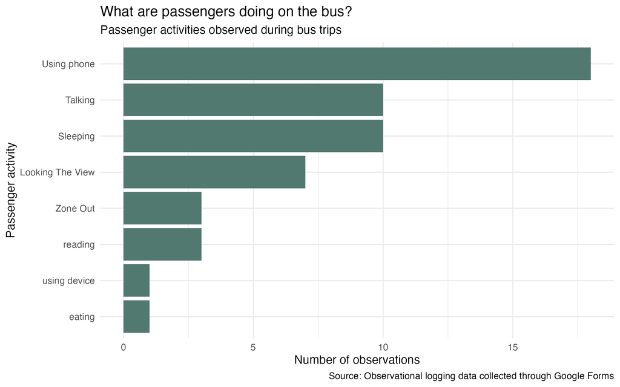

Bar chart showing passenger activities on the bus. Using phone was the most common activity, followed by talking and sleeping.

## Headphone use

This visualisation shows how frequently passengers were observed wearing headphones during bus trips.

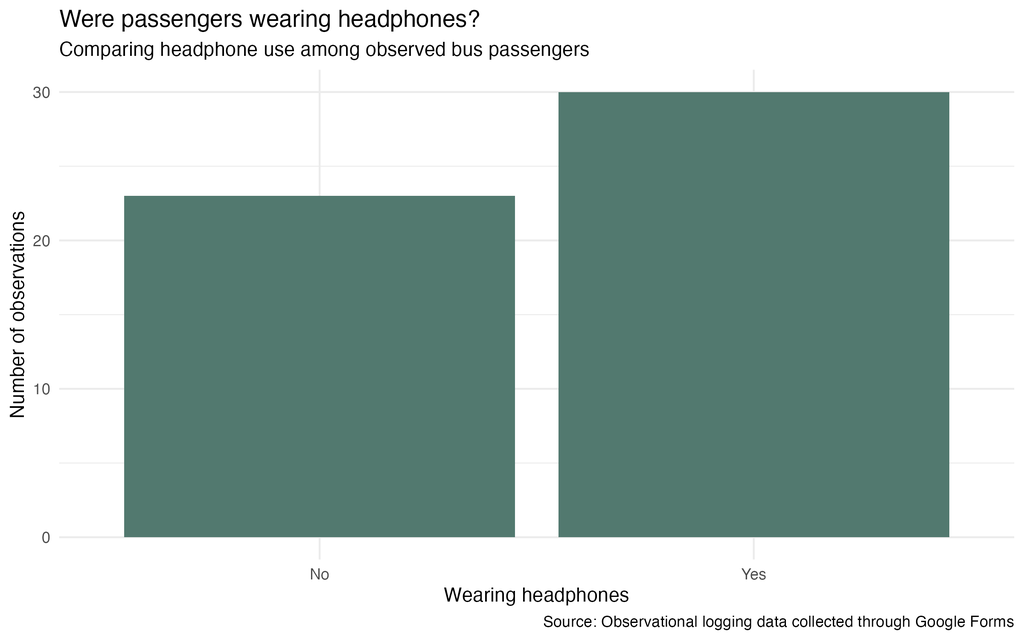

The use of headphones creates another layer to the story as it demonstrates that how passengers may create a more private and personal space while travelling in public. The group of people being observed wearing headphones appeared more focused on their own activities when compared to the individuals around them. Based on this, it suggest that many people will treat public transportation as some form of individual experience, rather than as a social environment. Although not every passenger wore headphones, the chart shows that headphone use was still very common throughout the observations.

## Trip duration and passenger activity

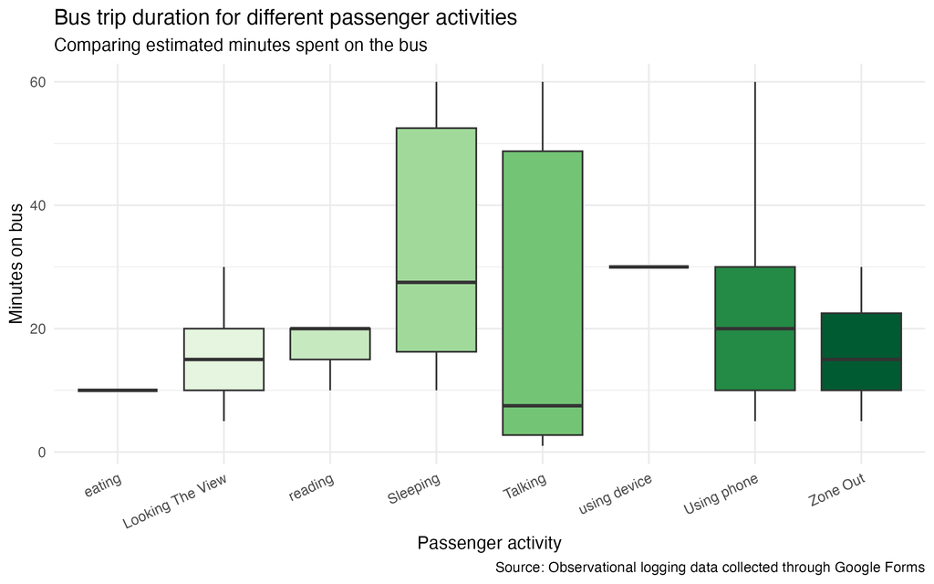

Boxplot comparing bus trip duration by passenger activity. Some activities show wider variation in trip duration than others.

The boxplot illustrates how different activities were connected with varying levels of estimated travel times. Sleeping and using a mobile device had greater representation across all of the trips than any other activity, thus it may indicate that passengers spent more time on these two activities if they rode for long periods of time. In contrast, activities such as eating appeared only occasionally and over shorter periods of time. There is still quite a lot of variation within each activity group, but the visualisation suggests that trip length may influence how passengers choose to spend their time.

## Time of day

The final visualisation shows when observations were most commonly recorded. This gives context for the data collection and helps explain when passenger behaviours were observed.

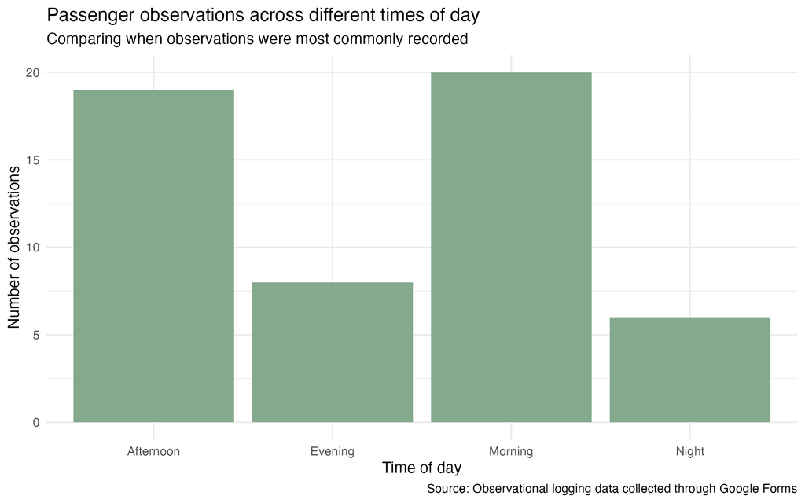

Bar chart showing the number of observations across different times of day. Morning and afternoon had the highest number of observations.

Most of the observations were recorded during the morning and afternoon periods, while fewer were collected during the evening and night. This was likely influenced by the times when I most often used public transport during the data collection process. Because the observations were shaped by my own travel routines, the visualisations are more representative of daytime commuting behaviour rather than late-night travel. Someone collecting data during peak-hour or late-night bus trips may have observed different passenger behaviours and activity patterns. This suggests that the patterns shown in the visualisations were influenced not only by passenger behaviour itself, but also by the context and timing of the data collection process.

## Overall story

Overall, the data suggests that bus passengers often use travel time for quiet individual activities, especially using phones, sleeping, or wearing headphones. The observations also show that passenger behaviour can vary depending on the length of the trip and the time of day.